# MyNewProject

Nabeel Ahmed nxa176@psu.edu

June 8, 2016

Let us write some code to generate random normals and draw a histogram

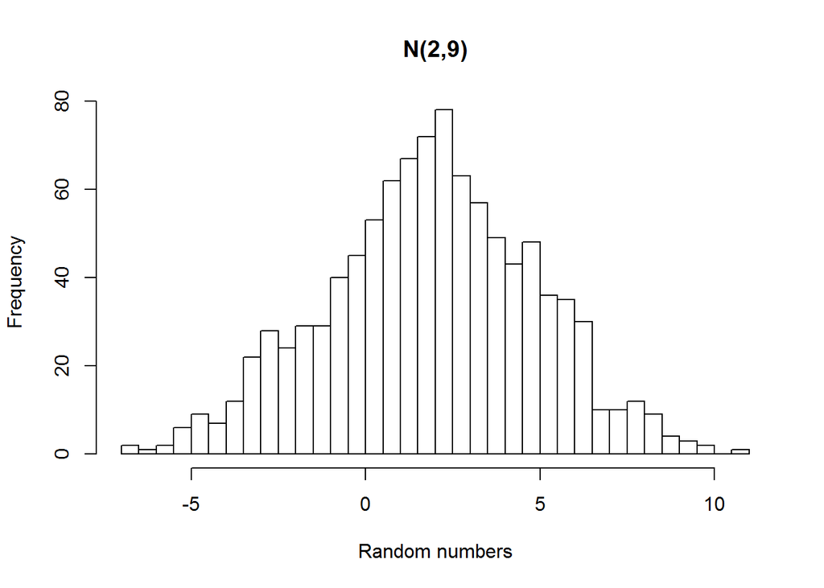

```r
x = rnorm(1000, mean=2, sd=3)
hist(x, main="N(2,9)", xlab="Random numbers", nclass=50)
```

## Simulation Study example

We first generate phenotypic scores randomly for 20 samples. We will have these phenotypic scores in *pheno*

```r
nsamp = 20
pheno = rnorm(nsamp)
```

Next we create a matrix for 1000 genes and gene expression data created randomly for the 20 samples.

```r
ngenes = 1000
genes = matrix(rnorm(ngenes*nsamp), ncol = nsamp)
```

We would like to compute the correlation between the phenotype score and the gene expression data

```r
trans = t(genes)
corr = cor(trans, pheno)
dim(corr)
```

```
## [1] 1000    1
```

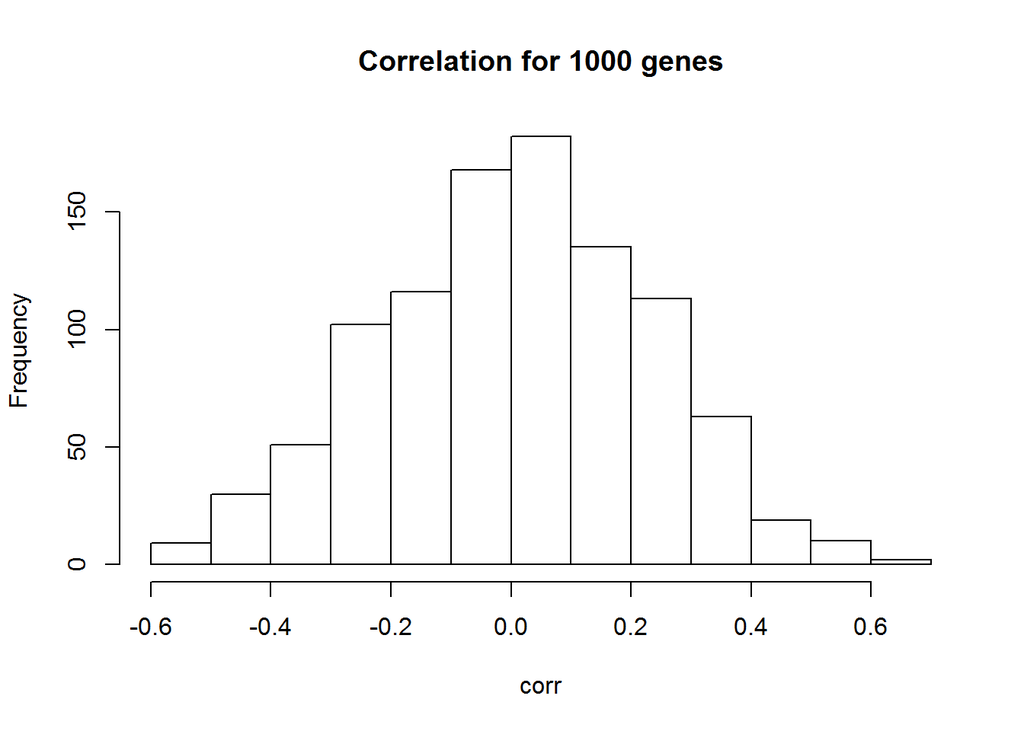

```r
hist(corr, main="Correlation for 1000 genes")
```

We select top 10 genes as these have the highest predictive power of phenotypic score from gene expression

```r
nsel = 10
selgenes = order(corr, decreasing = TRUE)[1:nsel]
sigGenes = genes[selgenes,]
```

We do linear regression analysis to get the $R^2$

```r
regout=lm(pheno~t(sigGenes))
R2=var(fitted(regout))/var(pheno)
anova(regout)
```

```
## Analysis of Variance Table
##
## Response: pheno
##             Df  Sum Sq Mean Sq F value    Pr(>F)
## t(sigGenes) 10 19.5004 1.95004  11.196 0.0006181 ***
## Residuals    9  1.5676 0.17417
## ---
## Signif. codes:  0 '***' 0.001 '**' 0.01 '*' 0.05 '.' 0.1 ' ' 1
```

```r
R2
```

```
## [1] 0.9255946
```

To generate a null distribution by running the simulation repeatedly

```r
simR2=function(nsamp=20,ngene=1000,nsel=10){
  if (nsel >= nsamp-1) stop("The number of genes selected must
                            be less than the sample size")
  pheno=rnorm(nsamp)
  genes=matrix(rnorm(nsamp*ngene),ncol=nsamp)
  cors=cor(t(genes),pheno)
  selgenes=order(cors,decreasing=TRUE)[1:nsel]
  sigGenes=genes[selgenes,]
  R2=var(fitted(lm(pheno~t(sigGenes))))/var(pheno)
  c(maxAbsR=max(abs(cors)),minR=min(cors),maxR=max(cors),Rsq=R2)
}
```

Now we run it for 1000 iterations

```r
# Create a 1000 row matrix whose 4 columns will contain the returned values from simR2 function
simN20G1000S10=matrix(nrow=1000,ncol=4)
for (i in 1:1000) simN20G1000S10[i,]=simR2(nsamp=20,ngene=1000,nsel=10)
```

We can view the plot of the sampling distribution for the absolute largest correlation, largest corrrelation, smallest correlation and $R^2$

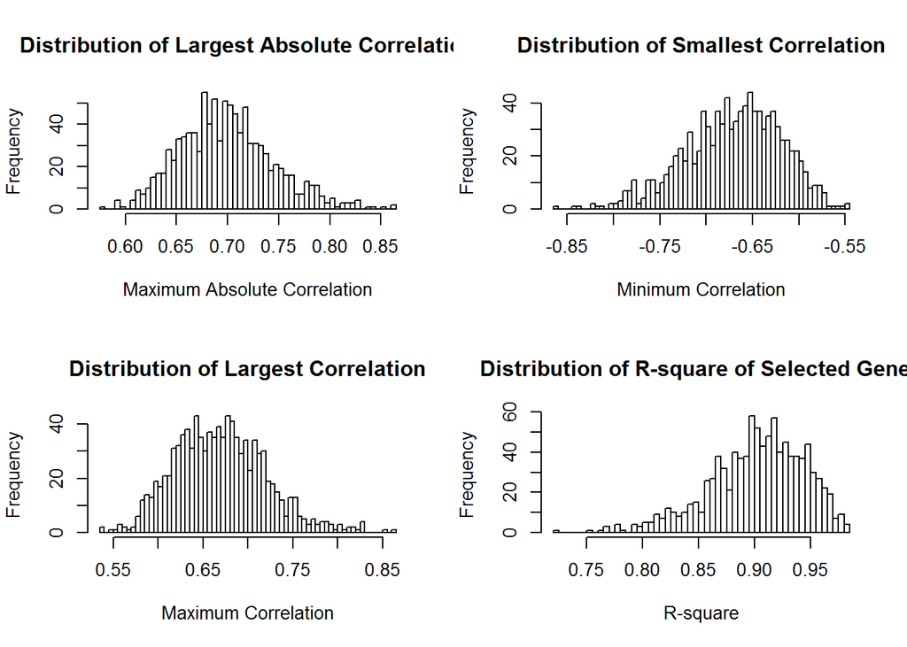

For example, if the largest absolute correlation between phenotypic score and gene expression is 0.68, the p-value for this is the proportion of our simulations that produced a value at least as large.

The p-value is 0.643.

Although the 0.68 would be a large correlation if there were only one gene being tested, it is a fairly typical value for the maximum when there are 1000.